# SPSS_Output_hmwk4Key

[output not shown]

Log  
Log - Log - November 12, 2017

GET  
FILE='C:\EMORY-SON\NRSG736_previousStatsSPSScourse\Fall2017\Homework04_key\helpmkh.sav'.  
DATASET NAME DataSet1 WINDOW=FRONT.  
REGRESSION  
/DESCRIPTIVES MEAN STDDEV CORR SIG N  
/MISSING LISTWISE  
/STATISTICS COEFF OUTS CI(95) R ANOVA COLLIN TOL CHANGE ZPP  
/CRITERIA=PIN(.05) POUT(.10)  
/NOORIGIN  
/DEPENDENT indtot  
/METHOD=ENTER mcs  
/RESIDUALS DURBIN HISTOGRAM(ZRESID) NORMPROB(ZRESID)  
/CASEWISE PLOT(ZRESID) OUTLIERS(3)  
/SAVE PRED ZPRED COOK RESID ZRESID.

Regression  
Regression - Active Dataset - November 12, 2017

[DataSet1] C:\EMORY-SON\NRSG736_previousStatsSPSScourse\Fall2017\Homework04_key\helpmkh.sav

Regression  
Regression - Descriptive Statistics - November 12, 2017

Descriptive StatisticsDescriptive Statistics, table, 1 levels of column headers and 1 levels of row headers, table with 4 columns and 4 rows

|  | Mean | Std. Deviation | N |
| --- | --- | --- | --- |
| indtot Inventory of Drug Use Consequences (InDue) total score - Baseline | 35.73 | 7.152 | 453 |
| mcs SF36 Mental Composite Score - Baseline | 31.676678300693336 | 12.839337307517013 | 453 |

Regression  
Regression - Correlations - November 12, 2017

CorrelationsCorrelations, table, 1 levels of column headers and 2 levels of row headers, table with 4 columns and 8 rows

|  |  | indtot Inventory of Drug Use Consequences (InDue) total score - Baseline | mcs SF36 Mental Composite Score - Baseline |
| --- | --- | --- | --- |
| Pearson Correlation | indtot Inventory of Drug Use Consequences (InDue) total score - Baseline | 1.000 | -.381 |
|  | mcs SF36 Mental Composite Score - Baseline | -.381 | 1.000 |
| Sig. (1-tailed) | indtot Inventory of Drug Use Consequences (InDue) total score - Baseline | . | .000 |
|  | mcs SF36 Mental Composite Score - Baseline | .000 | . |
| N | indtot Inventory of Drug Use Consequences (InDue) total score - Baseline | 453 | 453 |
|  | mcs SF36 Mental Composite Score - Baseline | 453 | 453 |

Regression  
Regression - Variables Entered/Removed - November 12, 2017

Variables Entered/Removed<sup>a</sup>Variables Entered/Removed, table, 1 levels of column headers and 1 levels of row headers, table with 4 columns and 5 rows

| Model | Variables Entered | Variables Removed | Method |
| --- | --- | --- | --- |
| 1 | mcs SF36 Mental Composite Score - Baseline<sup>b</sup> | . | Enter |

a. Dependent Variable: indtot Inventory of Drug Use Consequences (InDue) total score - Baseline  
b. All requested variables entered.

Regression  
Regression - Model Summary - November 12, 2017

Model Summary<sup>b</sup>Model Summary, table, 2 levels of column headers and 1 levels of row headers, table with 11 columns and 6 rows

| Model | R | R Square | Adjusted R Square | Std. Error of the Estimate | Change Statistics |  |  |  |  | Durbin-Watson |  |
| --- | --- | --- | --- | --- | --- | --- | --- | --- | --- | --- | --- |
|  |  |  |  |  | R Square Change | F Change | df1 | df2 | Sig. F Change |  |  |
| 1 | .381<sup>a</sup> | .145 | .143 | 6.621 | .145 | 76.407 | 1 | 451 | .000 |  | 2.048 |

a. Predictors: (Constant), mcs SF36 Mental Composite Score - Baseline  
b. Dependent Variable: indtot Inventory of Drug Use Consequences (InDue) total score - Baseline

Regression  
Regression - ANOVA - November 12, 2017

ANOVA<sup>a</sup>ANOVA, table, 1 levels of column headers and 2 levels of row headers, table with 7 columns and 7 rows

| Model |  | Sum of Squares | df | Mean Square | F | Sig. |
| --- | --- | --- | --- | --- | --- | --- |
| 1 | Regression | 3349.702 | 1 | 3349.702 | 76.407 | .000<sup>b</sup> |
|  | Residual | 19771.900 | 451 | 43.840 |  |  |
|  | Total | 23121.603 | 452 |  |  |  |

a. Dependent Variable: indtot Inventory of Drug Use Consequences (InDue) total score - Baseline  
b. Predictors: (Constant), mcs SF36 Mental Composite Score - Baseline

Regression  
Regression - Coefficients - November 12, 2017

Coefficients<sup>a</sup>Coefficients, table, 2 levels of column headers and 2 levels of row headers, table with 14 columns and 6 rows

| Model |  | Unstandardized Coefficients |  | Standardized Coefficients | t | Sig. | 95.0% Confidence Interval for B |  | Correlations |  |  | Collinearity Statistics |  |
| --- | --- | --- | --- | --- | --- | --- | --- | --- | --- | --- | --- | --- | --- |
|  |  | B | Std. Error | Beta |  |  | Lower Bound | Upper Bound | Zero-order | Partial | Part | Tolerance | VIF |
| 1 | (Constant) | 42.445 | .829 |  | 51.203 | .000 | 40.816 | 44.074 |  |  |  |  |  |
|  | mcs SF36 Mental Composite Score - Baseline | -.212 | .024 | -.381 | -8.741 | .000 | -.260 | -.164 | -.381 | -.381 | -.381 | 1.000 | 1.000 |

a. Dependent Variable: indtot Inventory of Drug Use Consequences (InDue) total score - Baseline

Regression  
Regression - Collinearity Diagnostics - November 12, 2017

Collinearity Diagnostics<sup>a</sup>Collinearity Diagnostics, table, 2 levels of column headers and 2 levels of row headers, table with 6 columns and 6 rows

| Model | Dimension | Eigenvalue | Condition Index | Variance Proportions |  |
| --- | --- | --- | --- | --- | --- |
|  |  |  |  | (Constant) | mcs SF36 Mental Composite Score - Baseline |
| 1 | 1 | 1.927 | 1.000 | .04 | .04 |
|  | 2 | .073 | 5.135 | .96 | .96 |

a. Dependent Variable: indtot Inventory of Drug Use Consequences (InDue) total score - Baseline

Regression  
Regression - Casewise Diagnostics - November 12, 2017

Casewise Diagnostics<sup>a</sup>Casewise Diagnostics, table, 1 levels of column headers and 1 levels of row headers, table with 5 columns and 10 rows

| Case Number | Std. Residual | indtot Inventory of Drug Use Consequences (InDue) total score - Baseline | Predicted Value | Residual |
| --- | --- | --- | --- | --- |
| 12 | -4.321 | 11 | 39.61 | -28.607 |
| 45 | -3.298 | 8 | 29.84 | -21.839 |
| 238 | -4.111 | 4 | 31.22 | -27.217 |
| 320 | -3.013 | 13 | 32.95 | -19.953 |
| 349 | -3.132 | 9 | 29.74 | -20.738 |
| 382 | -4.171 | 6 | 33.62 | -27.619 |
| 438 | -3.486 | 10 | 33.08 | -23.079 |

a. Dependent Variable: indtot Inventory of Drug Use Consequences (InDue) total score - Baseline

Regression  
Regression - Residuals Statistics - November 12, 2017

Residuals Statistics<sup>a</sup>Residuals Statistics, table, 1 levels of column headers and 1 levels of row headers, table with 6 columns and 15 rows

|  | Minimum | Maximum | Mean | Std. Deviation | N |
| --- | --- | --- | --- | --- | --- |
| Predicted Value | 29.26 | 41.01 | 35.73 | 2.722 | 453 |
| Std. Predicted Value | -2.375 | 1.940 | .000 | 1.000 | 453 |
| Standard Error of Predicted Value | .311 | .803 | .425 | .113 | 453 |
| Adjusted Predicted Value | 29.12 | 41.01 | 35.73 | 2.722 | 453 |
| Residual | -28.607 | 11.427 | .000 | 6.614 | 453 |
| Std. Residual | -4.321 | 1.726 | .000 | .999 | 453 |
| Stud. Residual | -4.335 | 1.735 | .000 | 1.002 | 453 |
| Deleted Residual | -28.800 | 11.544 | -.002 | 6.650 | 453 |
| Stud. Deleted Residual | -4.423 | 1.738 | -.002 | 1.006 | 453 |
| Mahal. Distance | .000 | 5.643 | .998 | 1.157 | 453 |
| Cook's Distance | .000 | .071 | .003 | .008 | 453 |
| Centered Leverage Value | .000 | .012 | .002 | .003 | 453 |

a. Dependent Variable: indtot Inventory of Drug Use Consequences (InDue) total score - Baseline

Charts  
Charts - *zresid Histogram - November 12, 2017

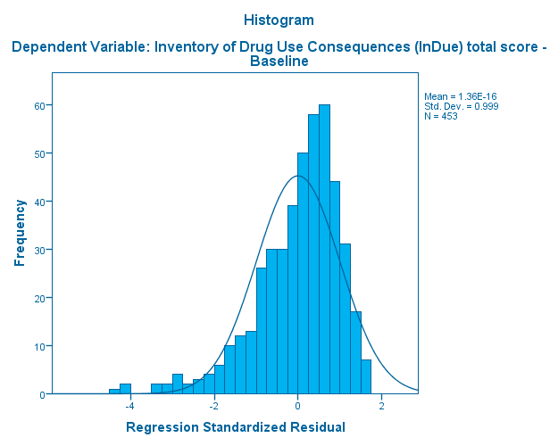

Charts  
Charts - *zresid Normal P-P Plot - November 12, 2017

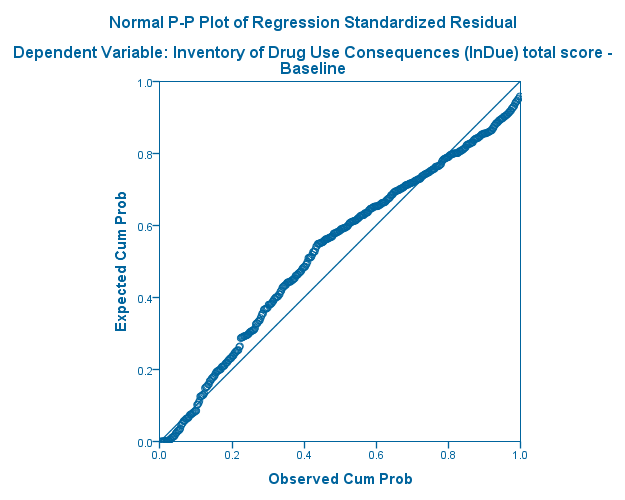

Log  
Log - Log - November 12, 2017

GRAPH  
/SCATTERPLOT(BIVAR)=ZPR_1 WITH ZRE_1  
/MISSING=LISTWISE.

Graph  
Graph - Scatter of ZRE_1 ZPR_1 - November 12, 2017

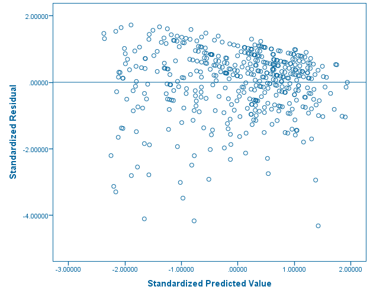


Log  
Log - Log - November 12, 2017

GRAPH  
/SCATTERPLOT(BIVAR)=id WITH COO_1  
/MISSING=LISTWISE.

Graph  
Graph - Scatter of COO_1 id - November 12, 2017

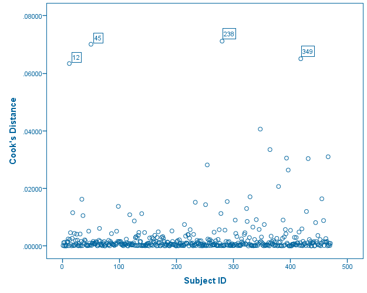

Log  
Log - Log - November 12, 2017

GRAPH  
/SCATTERPLOT(BIVAR)=id WITH ZRE_1  
/MISSING=LISTWISE.

Graph  
Graph - Scatter of ZRE_1 id - November 12, 2017

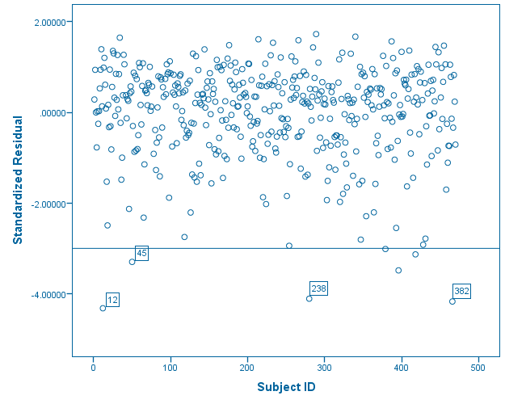

Log  
Log - Log - November 12, 2017

GRAPH  
/SCATTERPLOT(BIVAR)=mcs WITH indtot  
/MISSING=LISTWISE.

Graph  
Graph - Scatter of indtot mcs - November 12, 2017

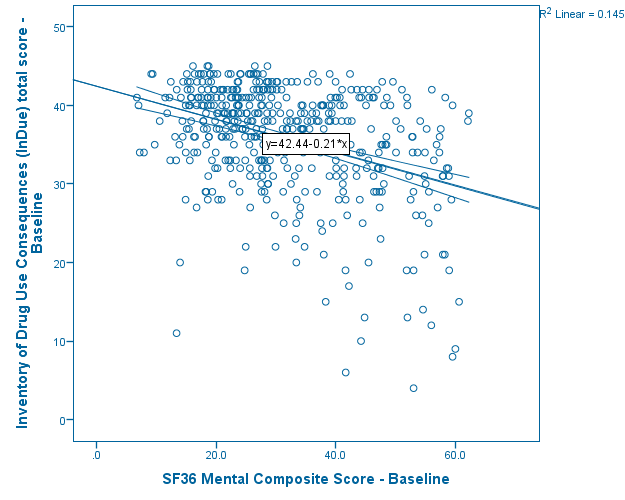

Log  
Log - Log - November 12, 2017

DATASET ACTIVATE DataSet1.  
SAVE OUTFILE='C:\EMORY-SON\NRSG736_previousStatsSPSScourse\Fall2017\Homework04_key\helpmkh.sav'  
/COMPRESSED.  
UNIANOVA indtot BY race3  
/METHOD=SSTYPE(3)  
/INTERCEPT=INCLUDE  
/POSTHOC=race3(SIDAK)  
/EMMEANS=TABLES(OVERALL)  
/EMMEANS=TABLES(race3)  
/PRINT=ETASQ HOMOGENEITY DESCRIPTIVE  
/CRITERIA=ALPHA(.05)  
/DESIGN=race3.

Univariate Analysis of Variance  
Univariate Analysis of Variance - Between-Subjects Factors - November 12, 2017

Between-Subjects FactorsBetween-Subjects Factors, table, 1 levels of column headers and 2 levels of row headers, table with 4 columns and 5 rows

|  |  | Value Label | N |
| --- | --- | --- | --- |
| race3 | 1 | black | 211 |
|  | 2 | hispanic/other | 76 |
|  | 4 | white | 166 |

Univariate Analysis of Variance  
Univariate Analysis of Variance - Descriptive Statistics - November 12, 2017

Descriptive StatisticsDescriptive Statistics, table, Dependent Variable, indtot Inventory of Drug Use Consequences (InDue) total score - Baseline, 1 layers, 1 levels of column headers and 1 levels of row headers, table with 4 columns and 7 rows

| indtot Inventory of Drug Use Consequences (InDue) total score - Baseline indtot Inventory of Drug Use Consequences (InDue) total score - Baseline |  |  |  |
| --- | --- | --- | --- |
| race3 | Mean | Std. Deviation | N |
| 1 black | 34.27 | 7.716 | 211 |
| 2 hispanic/other | 35.74 | 6.914 | 76 |
| 4 white | 37.58 | 6.039 | 166 |
| Total | 35.73 | 7.152 | 453 |

Univariate Analysis of Variance  
Univariate Analysis of Variance - Levene's Test of Equality of Error Variances - November 12, 2017

Levene's Test of Equality of Error Variances<sup>a</sup>Levene's Test of Equality of Error Variances, table, Dependent Variable, indtot Inventory of Drug Use Consequences (InDue) total score - Baseline, 1 layers, 1 levels of column headers and 0 levels of row headers, table with 4 columns and 6 rows

| indtot Inventory of Drug Use Consequences (InDue) total score - Baseline indtot Inventory of Drug Use Consequences (InDue) total score - Baseline |  |  |  |
| --- | --- | --- | --- |
| F | df1 | df2 | Sig. |
| 3.495 | 2 | 450 | .031 |

Tests the null hypothesis that the error variance of the dependent variable is equal across groups.  
a. Design: Intercept + race3

Univariate Analysis of Variance  
Univariate Analysis of Variance - Tests of Between-Subjects Effects - November 12, 2017

Tests of Between-Subjects EffectsTests of Between-Subjects Effects, table, Dependent Variable, indtot Inventory of Drug Use Consequences (InDue) total score - Baseline, 1 layers, 1 levels of column headers and 1 levels of row headers, table with 7 columns and 10 rows

| indtot Inventory of Drug Use Consequences (InDue) total score - Baseline indtot Inventory of Drug Use Consequences (InDue) total score - Baseline |  |  |  |  |  |  |
| --- | --- | --- | --- | --- | --- | --- |
| Source | Type III Sum of Squares | df | Mean Square | F | Sig. | Partial Eta Squared |
| Corrected Model | 1016.782<sup>a</sup> | 2 | 508.391 | 10.350 | .000 | .044 |
| Intercept | 483860.948 | 1 | 483860.948 | 9850.224 | .000 | .956 |
| race3 | 1016.782 | 2 | 508.391 | 10.350 | .000 | .044 |
| Error | 22104.821 | 450 | 49.122 |  |  |  |
| Total | 601387.000 | 453 |  |  |  |  |
| Corrected Total | 23121.603 | 452 |  |  |  |  |

a. R Squared = .044 (Adjusted R Squared = .040)

Estimated Marginal Means  
Estimated Marginal Means - 1. Grand Mean - November 12, 2017

1. Grand Mean1. Grand Mean, table, Dependent Variable, indtot Inventory of Drug Use Consequences (InDue) total score - Baseline, 1 layers, 2 levels of column headers and 0 levels of row headers, table with 4 columns and 5 rows

| indtot Inventory of Drug Use Consequences (InDue) total score - Baseline indtot Inventory of Drug Use Consequences (InDue) total score - Baseline |  |  |  |
| --- | --- | --- | --- |
| Mean | Std. Error | 95% Confidence Interval |  |
|  |  | Lower Bound | Upper Bound |
| 35.862 | .361 | 35.152 | 36.572 |

Estimated Marginal Means  
Estimated Marginal Means - 2. race3 - November 12, 2017

2. race32. race3, table, Dependent Variable, indtot Inventory of Drug Use Consequences (InDue) total score - Baseline, 1 layers, 2 levels of column headers and 1 levels of row headers, table with 5 columns and 7 rows

| indtot Inventory of Drug Use Consequences (InDue) total score - Baseline indtot Inventory of Drug Use Consequences (InDue) total score - Baseline |  |  |  |  |
| --- | --- | --- | --- | --- |
| race3 | Mean | Std. Error | 95% Confidence Interval |  |
|  |  |  | Lower Bound | Upper Bound |
| 1 black | 34.270 | .482 | 33.322 | 35.218 |
| 2 hispanic/other | 35.737 | .804 | 34.157 | 37.317 |
| 4 white | 37.578 | .544 | 36.509 | 38.647 |

race3  
race3 - Multiple Comparisons - November 12, 2017

Multiple ComparisonsMultiple Comparisons, table, Dependent Variable, indtot Inventory of Drug Use Consequences (InDue) total score - Baseline, Sidak, 1 layers, 2 levels of column headers and 2 levels of row headers, table with 7 columns and 13 rows

| indtot Inventory of Drug Use Consequences (InDue) total score - Baseline indtot Inventory of Drug Use Consequences (InDue) total score - Baseline Sidak Sidak |  |  |  |  |  |  |
| --- | --- | --- | --- | --- | --- | --- |
| (I) race3 | (J) race3 | Mean Difference (I-J) | Std. Error | Sig. | 95% Confidence Interval |  |
|  |  |  |  |  | Lower Bound | Upper Bound |
| 1 black | 2 hispanic/other | -1.47 | .938 | .315 | -3.71 | .78 |
|  | 4 white | -3.31* | .727 | .000 | -5.05 | -1.57 |
| 2 hispanic/other | 1 black | 1.47 | .938 | .315 | -.78 | 3.71 |
|  | 4 white | -1.84 | .971 | .165 | -4.17 | .48 |
| 4 white | 1 black | 3.31* | .727 | .000 | 1.57 | 5.05 |
|  | 2 hispanic/other | 1.84 | .971 | .165 | -.48 | 4.17 |

Based on observed means. The error term is Mean Square(Error) = 49.122.  
*. The mean difference is significant at the .05 level.

Log  
Log - Log - November 12, 2017

GRAPH  
/ERRORBAR(CI 95)=indtot BY race3.

Graph  
Graph - Error Bar of indtot by race3 - November 12, 2017

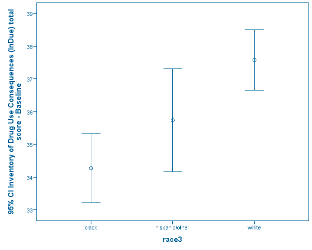

X

Created Using: IBM SPSS Statistics 23

Creation Date: Nov 12, 2017

Document Version: Original

Saved Date: Nov 12, 2017

Navigation Controls

Help - Opens Help

Toolbar Buttons

[output not shown]

Connecting to a Server

Editing Tables

[output not shown]

Editing Charts

[output not shown]

Save

Server Connection

X  
Saved Server Connections

Status

Pivot and Sort

Chart Size

[output not shown]

Background

Line and Borders

Text Format

Number Format

[output not shown]

Axis Options

[output not shown]